# Library Importing

```python
import numpy as np
import matplotlib.pyplot as plt
import pandas as pd
```

### 1. Create a NumPy array of numbers from 1 to 10 and print it.

```python
arr=np.array([],dtype=int)
for i in range(1,11):
    arr=np.append(arr,i)
print(arr)
```

```
[ 1  2  3  4  5  6  7  8  9 10]
```

### 2. Create a 3×3 matrix filled with zeros and another filled with ones.

```python
arr_zero= np.zeros((3,3))
arr_one=np.ones((3,3))
print(f"Matrix with zeros:\n {arr_zero}")
print()
print(f"Matrix with ones:\n {arr_one}")
```

```
Matrix with zeros:
 [[0. 0. 0.]
 [0. 0. 0.]
 [0. 0. 0.]]

Matrix with ones:
 [[1. 1. 1.]
 [1. 1. 1.]
 [1. 1. 1.]]
```

### 3. Generate an array of 5 random numbers between 0 and 1.

```python
arr_random = np.random.random(5)
print(arr_random)
```

```
[0.13982492 0.44975963 0.04216715 0.68109624 0.06164201]
```

### 4. Find the sum, mean, minimum, and maximum of a NumPy array.

```python
arr= np.random.randint(1,11,size=10)
print(f"Sum = {np.sum(arr)}")
print(f"Mean = {np.mean(arr)}")
print(f"Median = {np.median(arr)}")
print(f"Minimum = {np.min(arr)}")
print(f"Maximum = {np.max(arr)}")
```

```
Sum = 49
Mean = 4.9
Median = 5.0
Minimum = 1
Maximum = 10
```

### 5. Reshape a 1D array of 12 elements into a 3×4 matrix.

```python
arr_random = np.random.randint(1,6,size=12)
print(f"original array = {arr_random}")
print(f"Reshaping :\n {arr_random.reshape(3,4)}")
```

```
original array = [4 4 5 1 3 3 1 4 4 4 2 1]
Reshaping :
 [[4 4 5 1]
 [3 3 1 4]
 [4 4 2 1]]
```

### 6. Multiply two arrays element-wise and print the result.

```python
a = np.array([1,2,3])
b = np.array([4,5,6])

result = a*b
print(f"Product = \n {result}")
```

```
Product =
 [ 4 10 18]
```

### 7. Slice the first 3 elements and the last 3 elements from an array.

```python
a = np.array([1,2,3,4,5,6,7,8,9,0])

print(np.concatenate((a[:3],a[-3:])))
```

```
[1 2 3 8 9 0]
```

### 8. Create an identity matrix of size 4×4 using NumPy.

```python
a = np.eye(4)
print(a)
```

```
[[1. 0. 0. 0.]
 [0. 1. 0. 0.]
 [0. 0. 1. 0.]
 [0. 0. 0. 1.]]
```

# Pandas

### 1. Create a Pandas DataFrame with columns: Name, Age, City, and Salary.

```python
df = pd.DataFrame({
    "name": ["Hari", "Priya", "Arjun", "Anita", "Rajeev", "Sita", "Mohan", "Deepak", "Nisha", "Ramesh"],
    "age": [25, 30, 28, 26, 32, 29, 35, 24, 27, 31],
    "city": ["Kathmandu", "Pokhara", "Lalitpur", "Bhaktapur", "Janakpur", "Dhulikhel", "Narayanghat", "Hetauda", "Itahari", "Birgunj"],
    "salary": [12000, 27500, 38900, 45000, 59800, 72000, 81500, 93200, 98000, 99999],
})

print(df)
```

```
     name  age         city  salary
0    Hari   25    Kathmandu   12000
1   Priya   30      Pokhara   27500
2   Arjun   28     Lalitpur   38900
3   Anita   26    Bhaktapur   45000
4  Rajeev   32     Janakpur   59800
5    Sita   29    Dhulikhel   72000
6   Mohan   35  Narayanghat   81500
7  Deepak   24      Hetauda   93200
8   Nisha   27      Itahari   98000
9  Ramesh   31      Birgunj   99999
```

### 2. Display the first 5 rows and last 3 rows of a DataFrame.

```python
print(pd.concat([df.head(5), df.tail(3)]))
```

```
     name  age       city  salary
0    Hari   25  Kathmandu   12000
1   Priya   30    Pokhara   27500
2   Arjun   28   Lalitpur   38900
3   Anita   26  Bhaktapur   45000
4  Rajeev   32   Janakpur   59800
7  Deepak   24    Hetauda   93200
8   Nisha   27    Itahari   98000
9  Ramesh   31    Birgunj   99999
```

### 3. Check the shape, data types, and basic statistics of a DataFrame using info() and describe().

```python
print(df.info())
print(df.describe())
```

```
<class 'pandas.DataFrame'>
RangeIndex: 10 entries, 0 to 9
Data columns (total 4 columns):
 #   Column  Non-Null Count  Dtype
---  ------  --------------  -----
 0   name    10 non-null     str
 1   age     10 non-null     int64
 2   city    10 non-null     str
 3   salary  10 non-null     int64
dtypes: int64(2), str(2)
memory usage: 452.0 bytes
None
            age        salary
count  10.00000     10.000000
mean   28.70000  62789.900000
std     3.40098  31100.329725
min    24.00000  12000.000000
25%    26.25000  40425.000000
50%    28.50000  65900.000000
75%    30.75000  90275.000000
max    35.00000  99999.000000
```

### 4. Select a single column and multiple columns from a DataFrame.

```python
print(f"Selecting single column:\n{df["name"]}")
print(f"\nSelecting multiple columns:\n{df.loc[:,["name","city","salary"]]}")
```

```
Selecting single column:
0      Hari
1     Priya
2     Arjun
3     Anita
4    Rajeev
5      Sita
6     Mohan
7    Deepak
8     Nisha
9    Ramesh
Name: name, dtype: str

Selecting multiple columns:
     name         city  salary
0    Hari    Kathmandu   12000
1   Priya      Pokhara   27500
2   Arjun     Lalitpur   38900
3   Anita    Bhaktapur   45000
4  Rajeev     Janakpur   59800
5    Sita    Dhulikhel   72000
6   Mohan  Narayanghat   81500
7  Deepak      Hetauda   93200
8   Nisha      Itahari   98000
9  Ramesh      Birgunj   99999
```

### 5. Filter rows where Salary is greater than 40000.

```python
print(df.loc[df["salary"]>40000])
```

```
     name  age         city  salary
3   Anita   26    Bhaktapur   45000
4  Rajeev   32     Janakpur   59800
5    Sita   29    Dhulikhel   72000
6   Mohan   35  Narayanghat   81500
7  Deepak   24      Hetauda   93200
8   Nisha   27      Itahari   98000
9  Ramesh   31      Birgunj   99999
```

### 6. Add a new column 'Tax' which is 10% of Salary.

```python
df["tax"] = 0.1*df["salary"]
print(df)
```

```
     name  age         city  salary     tax
0    Hari   25    Kathmandu   12000  1200.0
1   Priya   30      Pokhara   27500  2750.0
2   Arjun   28     Lalitpur   38900  3890.0
3   Anita   26    Bhaktapur   45000  4500.0
4  Rajeev   32     Janakpur   59800  5980.0
5    Sita   29    Dhulikhel   72000  7200.0
6   Mohan   35  Narayanghat   81500  8150.0
7  Deepak   24      Hetauda   93200  9320.0
8   Nisha   27      Itahari   98000  9800.0
9  Ramesh   31      Birgunj   99999  9999.9
```

### 7. Sort the DataFram by Age in ascending order

```python
print(df.sort_values("age"))
```

```
     name  age         city  salary     tax
7  Deepak   24      Hetauda   93200  9320.0
0    Hari   25    Kathmandu   12000  1200.0
3   Anita   26    Bhaktapur   45000  4500.0
8   Nisha   27      Itahari   98000  9800.0
2   Arjun   28     Lalitpur   38900  3890.0
5    Sita   29    Dhulikhel   72000  7200.0
1   Priya   30      Pokhara   27500  2750.0
9  Ramesh   31      Birgunj   99999  9999.9
4  Rajeev   32     Janakpur   59800  5980.0
6   Mohan   35  Narayanghat   81500  8150.0
```

### 8. Find and count missing values in each column using isnull().sum().

```python
df.loc[3:5:2,"salary"]=None
df.iloc[2,1]=None
print(df.isnull())
print(f"Number of missing value:\n{df.isnull().sum()}")
```

```
    name    age   city  salary    tax
0  False  False  False   False  False
1  False  False  False   False  False
2  False   True  False   False  False
3  False  False  False    True  False
4  False  False  False   False  False
5  False  False  False    True  False
6  False  False  False   False  False
7  False  False  False   False  False
8  False  False  False   False  False
9  False  False  False   False  False
Number of missing value:
name      0
age       1
city      0
salary    2
tax       0
dtype: int64
```

### 9. Replace missing values in a numeric column with the column mean.

```python
df["age"] = pd.to_numeric(df["age"], errors="coerce")
df["salary"] = pd.to_numeric(df["salary"], errors="coerce")

df = df.fillna(df.mean(numeric_only=True))
print(df)
```

```
     name        age         city     salary     tax
0    Hari  25.000000    Kathmandu  12000.000  1200.0
1   Priya  30.000000      Pokhara  27500.000  2750.0
2   Arjun  28.777778     Lalitpur  38900.000  3890.0
3   Anita  26.000000    Bhaktapur  63862.375  4500.0
4  Rajeev  32.000000     Janakpur  59800.000  5980.0
5    Sita  29.000000    Dhulikhel  63862.375  7200.0
6   Mohan  35.000000  Narayanghat  81500.000  8150.0
7  Deepak  24.000000      Hetauda  93200.000  9320.0
8   Nisha  27.000000      Itahari  98000.000  9800.0
9  Ramesh  31.000000      Birgunj  99999.000  9999.9
```

### 10. Group data by City and find the average Salary per City.

```python
group_by_cities = df.groupby("city")
print(f"\nAverage Salary per City:")
print(group_by_cities["salary"].mean())
```

```
Average Salary per City:
city
Bhaktapur      63862.375
Birgunj        99999.000
Dhulikhel      63862.375
Hetauda        93200.000
Itahari        98000.000
Janakpur       59800.000
Kathmandu      12000.000
Lalitpur       38900.000
Narayanghat    81500.000
Pokhara        27500.000
Name: salary, dtype: float64
```

# Matplotlib Visualization

### 1. Plot a simple line graph showing numbers 1 to 10 on both axes.

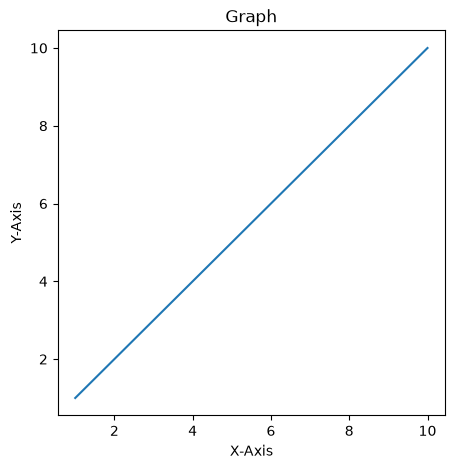

```python
x = [1,2,3,4,5,6,7,8,9,10]

plt.figure(figsize=(5,5))
plt.plot(x,x)
plt.xlabel("X-Axis")
plt.ylabel("Y-Axis")
plt.title("Graph")
plt.show()
```

### 2. Create a bar chart showing marks of 5 students.

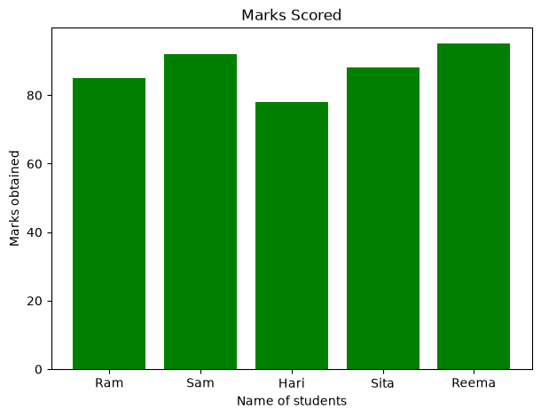

```python
marks = [85, 92, 78, 88, 95]
students = ["Ram", "Sam", "Hari", "Sita", "Reema"]

plt.figure(figsize=(7,5))
plt.bar(students, marks, color='green')
plt.title("Marks Scored")
plt.xlabel("Name of students")
plt.ylabel("Marks obtained")
plt.show()
```

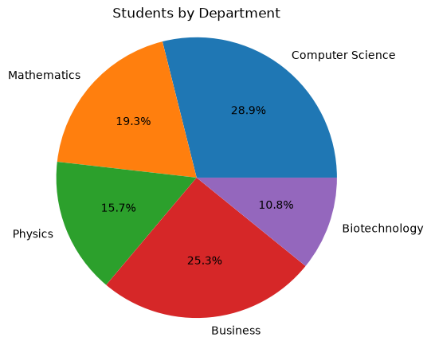

```python
departments = {
    "Computer Science": 120,
    "Mathematics": 80,
    "Physics": 65,
    "Business": 105,
    "Biotechnology": 45
}

plt.figure(figsize=(5,5))
plt.pie(departments.values(), labels = departments.keys(), autopct="%1.1f%%")
plt.title("Students by Department")
plt.axis('equal')
plt.show()
```

### 4. Plot a histogram for 100 random numbers to see the distribution.

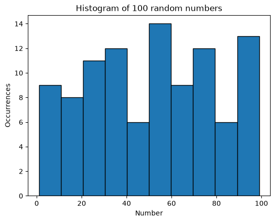

```python
arr = np.random.randint(1,100, size = 100)

plt.title("Histogram of 100 random numbers")
plt.xlabel("Number")
plt.ylabel("Occurrences")
plt.hist(arr, bins=10, edgecolor='black')
plt.show()
```

### 5. Create a scatter plot between Age and Salary from a sample dataset.

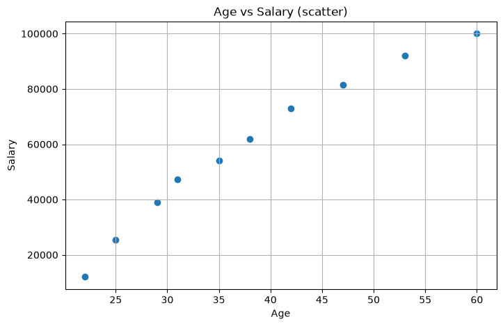

```python
data = {
    "age":    [22, 25, 29, 31, 35, 38, 42, 47, 53, 60],
    "salary": [12000, 25500, 38900, 47200, 54000, 61800, 73000, 81500, 92000, 99999],
}

plt.figure(figsize=(8,5))
plt.scatter(data["age"], data["salary"])
plt.title('Age vs Salary (scatter)')
plt.xlabel('Age')
plt.ylabel('Salary')
plt.grid(True)
plt.show()
```

### 6. Plot two lines on the same graph and add a legend.

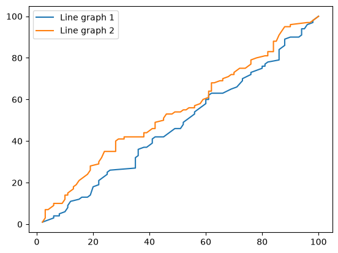

```python
x1 = np.sort(np.random.randint(1,101,size=100))
y1 = np.sort(np.random.randint(1,101,size=100))

x2 = np.sort(np.random.randint(1,101,size=100))
y2 = np.sort(np.random.randint(1,101,size=100))

plt.plot(x1,y1,label = "Line graph 1")
plt.plot(x2,y2, label = "Line graph 2")
plt.legend()
plt.show()
```

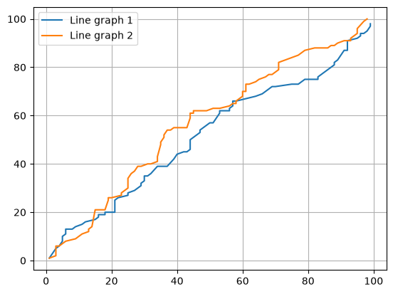

```python
x1 = np.sort(np.random.randint(1,101,size=100))
y1 = np.sort(np.random.randint(1,101,size=100))

x2 = np.sort(np.random.randint(1,101,size=100))
y2 = np.sort(np.random.randint(1,101,size=100))

plt.plot(x1,y1,label = "Line graph 1")
plt.plot(x2,y2, label = "Line graph 2")
plt.legend()
plt.grid(True)
plt.show()
```

### 8. Use subplots to display a line chart and a bar chart side by side.

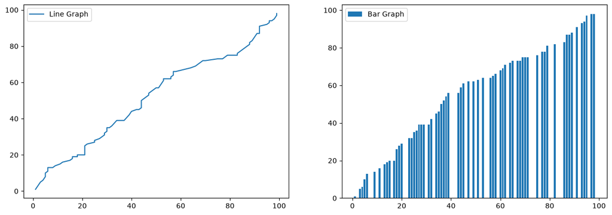

```python
plt.figure(figsize=(15,5))
plt.subplot(1,2,1)
plt.plot(x1,y1,label="Line Graph")
plt.legend()

plt.subplot(1,2,2)
plt.bar(x2,y1,label="Bar Graph")
plt.legend()

plt.show()
```

# Reading & Cleaning CSV Files

### 1. Read a CSV file using pandas read_csv() and display its contents.

```python
df = pd.read_csv('students_marks.csv')
print(df)
```

```
      NAME GENDER  MATH  SCIENCE  ENGLISH  HISTORY
0      Ram      M  85.0     90.0       78     88.0
1     Sita      F  92.0      NaN       81     75.0
2    Arjun      M  74.0     68.0       70     72.0
3    Priya      F  88.0     91.0       89      NaN
4    Mohan      M   NaN     72.0       65     70.0
5    Anita      F  95.0     89.0       93     90.0
6    Nisha      F  88.0     85.0       84     82.0
7      Ram      M  85.0     90.0       78     88.0
8     Sita      F  92.0      NaN       81     75.0
9    Misha      F  80.0     76.0       79     85.0
10  Ramesh      M  74.0     68.0       70     72.0
```

### 2. Print the column names, number of rows, and number of columns.

```python
print(f"Column Names = {df.columns}")
print(f"Number of columns = {len(df.columns)}")
print(f"Number of rows = {len(df)}")
```

```
Column Names = Index(['NAME', 'GENDER', 'MATH', 'SCIENCE', 'ENGLISH', 'HISTORY'], dtype='str')
Number of columns = 6
Number of rows = 11
```

### 3. Display the first 5 rows and check for missing values.

```python
print(df[:5])

print("\nCheck for missing values:")
print(df.isnull())
```

```
    NAME GENDER  MATH  SCIENCE  ENGLISH  HISTORY
0    Ram      M  85.0     90.0       78     88.0
1   Sita      F  92.0      NaN       81     75.0
2  Arjun      M  74.0     68.0       70     72.0
3  Priya      F  88.0     91.0       89      NaN
4  Mohan      M   NaN     72.0       65     70.0

Check for missing values:
     NAME  GENDER   MATH  SCIENCE  ENGLISH  HISTORY
0   False   False  False    False    False    False
1   False   False  False     True    False    False
2   False   False  False    False    False    False
3   False   False  False    False    False     True
4   False   False   True    False    False    False
5   False   False  False    False    False    False
6   False   False  False    False    False    False
7   False   False  False    False    False    False
8   False   False  False     True    False    False
9   False   False  False    False    False    False
10  False   False  False    False    False    False
```

### 4. Drop rows that contain any missing values using dropna().

```python
df_dropped_na = df.dropna()
print(df_dropped_na)
```

```
      NAME GENDER  MATH  SCIENCE  ENGLISH  HISTORY
0      Ram      M  85.0     90.0       78     88.0
2    Arjun      M  74.0     68.0       70     72.0
5    Anita      F  95.0     89.0       93     90.0
6    Nisha      F  88.0     85.0       84     82.0
7      Ram      M  85.0     90.0       78     88.0
9    Misha      F  80.0     76.0       79     85.0
10  Ramesh      M  74.0     68.0       70     72.0
```

### 5. Fill missing numeric values with the column mean using fillna().

```python
for cols in df.columns:
    try:
        df[cols] = pd.to_numeric(df[cols])
    except ValueError:
        pass
df = df.fillna(df.mean(numeric_only=True))
print(df)
```

```
      NAME GENDER  MATH  SCIENCE  ENGLISH  HISTORY
0      Ram      M  85.0     90.0       78     88.0
1     Sita      F  92.0     81.0       81     75.0
2    Arjun      M  74.0     68.0       70     72.0
3    Priya      F  88.0     91.0       89     79.7
4    Mohan      M  85.3     72.0       65     70.0
5    Anita      F  95.0     89.0       93     90.0
6    Nisha      F  88.0     85.0       84     82.0
7      Ram      M  85.0     90.0       78     88.0
8     Sita      F  92.0     81.0       81     75.0
9    Misha      F  80.0     76.0       79     85.0
10  Ramesh      M  74.0     68.0       70     72.0
```

### 6. Remove duplicate rows from the dataset.

```python
df = df.drop_duplicates()
print(df)
```

```
      NAME GENDER  MATH  SCIENCE  ENGLISH  HISTORY
0      Ram      M  85.0     90.0       78     88.0
1     Sita      F  92.0     81.0       81     75.0
2    Arjun      M  74.0     68.0       70     72.0
3    Priya      F  88.0     91.0       89     79.7
4    Mohan      M  85.3     72.0       65     70.0
5    Anita      F  95.0     89.0       93     90.0
6    Nisha      F  88.0     85.0       84     82.0
9    Misha      F  80.0     76.0       79     85.0
10  Ramesh      M  74.0     68.0       70     72.0
```

### 7. Rename column headers to lowercase using str.lower().

```python
df.columns= df.columns.str.lower()
print(df)
```

```
      name gender  math  science  english  history
0      Ram      M  85.0     90.0       78     88.0
1     Sita      F  92.0     81.0       81     75.0
2    Arjun      M  74.0     68.0       70     72.0
3    Priya      F  88.0     91.0       89     79.7
4    Mohan      M  85.3     72.0       65     70.0
5    Anita      F  95.0     89.0       93     90.0
6    Nisha      F  88.0     85.0       84     82.0
9    Misha      F  80.0     76.0       79     85.0
10  Ramesh      M  74.0     68.0       70     72.0
```

### 8. Convert a categorical column (e.g. Gender: Male/Female) into numbers using map() or replace().

```python
temp = df.copy()
df["gender"] = temp["gender"].map({"M": 1, "F": 0})
print(f"{df}\n")
df["gender"] = temp["gender"].replace({"M": 1, "F": 0})
print(df)
```

```
      name  gender  math  science  english  history
0      Ram       1  85.0     90.0       78     88.0
1     Sita       0  92.0     81.0       81     75.0
2    Arjun       1  74.0     68.0       70     72.0
3    Priya       0  88.0     91.0       89     79.7
4    Mohan       1  85.3     72.0       65     70.0
5    Anita       0  95.0     89.0       93     90.0
6    Nisha       0  88.0     85.0       84     82.0
9    Misha       0  80.0     76.0       79     85.0
10  Ramesh       1  74.0     68.0       70     72.0

      name gender  math  science  english  history
0      Ram      1  85.0     90.0       78     88.0
1     Sita      0  92.0     81.0       81     75.0
2    Arjun      1  74.0     68.0       70     72.0
3    Priya      0  88.0     91.0       89     79.7
4    Mohan      1  85.3     72.0       65     70.0
5    Anita      0  95.0     89.0       93     90.0
6    Nisha      0  88.0     85.0       84     82.0
9    Misha      0  80.0     76.0       79     85.0
10  Ramesh      1  74.0     68.0       70     72.0
```

### 9. Select only numeric columns and print their correlation using corr().

```python
df_num=df.select_dtypes(include="number")
print(df_num.corr())
```

```
             math   science   english   history
math     1.000000  0.777479  0.720853  0.493044
science  0.777479  1.000000  0.842335  0.764188
english  0.720853  0.842335  1.000000  0.749091
history  0.493044  0.764188  0.749091  1.000000
```

### 10. Save the cleaned DataFrame to a new CSV file using to_csv().

```python
df.to_csv("Cleaned_Students_marks.csv",index=False)
```